[figure not shown]

# ProjectCS361-Fall 2021 A* Algorithm

The most commonly used concept in AI is “ *graph searching* “. Graphsearching is used in different domains, such as gaming , machine learningand networking. Generally ,there are two types of searching algorithm either uninformed search that has no knowledge of the goal or informed search . The objective of this report is to explain A* algorithm whic hbelongs to an informed search algorithm that has information about thegoal using heuristic function to guarantee finding an optimal solution ifthe heuristic function was admissible .  
المفهوم الأكثر استخدامًا في الذكاء الاصطناعي هو "البحث بواسطة الرسم البياني". يُستخدم البحث بواسطة الرسم البياني في مجالات مختلفة ، مثل الألعاب والتعلم الآلي والشبكات. بشكل عام ، هناك نوعان من خوارزمية البحث إما البحث غير الواعي الذي ليس لديه معرفة بالهدف أو البحث المستنير. الهدف من هذا التقرير هو شرح خوارزمية "اي ستار " التي تنتمي الى خوارزميات البحث المستنير بالتالي هي تضمن ايجاد حل مثالي باقل تكلفة باستخدام معادلة ترشدنا الى اتجاه الهدف .

the problem is about a **Client** who wishes to communicate with the **Server** and sends packets , so we want to find an optimal path to the Server .Initially , we implement Forwarding Table for the client which works on A* algorithm ;assuming all routers has complete topology about link cost information.

المشكلة تتعلق بالعميل الذي يرغب في التواصل مع الخادم وإرسال الحزم ، لذلك نريد إيجاد المسار الأمثل للخادم. في البداية ، نقوم بتنفيذ جدول التوزيع للعميل الذي يعمل على خوارزمية اي ستار ؛ بافتراض أن جميع أجهزة التوجيه لديها المعلومات الكاملة عن المسار وتكلفته.

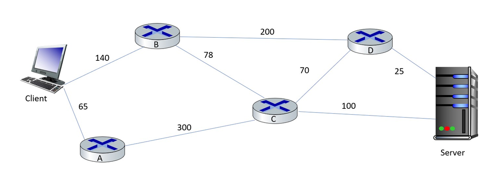

2.1.1. **Initial state:** The initial state in the problem is the client.  
الحالة الابتدائية : العميل  
2.1.2.**Goal state:** The final state we want to reach to it is Server.  
الحالة النهائية : الخادم  
2.1.3.**Action:** send packet from client to server from one router to another with minimum cost.  
الإجراء: إرسال حزمة من العميل إلى الخادم من جهاز توجيه إلى آخر بأقل تكلفة.  
2.1.4.**State space:** router connection with link and the packet go through it.  
الصورة الكلية للحالات :راوتر مربوط بسلك نقل الطاقة و الحزمة تمر من خلاله  
2.1.5.**Solution:** a path from client to the server with minimum cost.  
الحل : ايجاد اقصر مسار من العميل الى الخادم  
2.1.6.**Path cost function:** the length of a link in kilo meters.  
وحدة قياس المسافة : الكيلو متر

We calculate two heuristics one is admissible and the other one is not admissible to see the differences of the outout that will come .

We ensure to use addmisable and consistent heuristic depending on the statments of :  
**Admissible heuristic :** $ h(n)<= Cost(n,Goal) $  
**Consistent heuristic :** $ h(n)<=Cost(n,n’)+h(n’) $ For every Successor n' of n

| Client Path | Real Cost |
| --- | --- |
| Client -> B->D->Server | 365 |
| CLIENT ->B->C->D->Server | 313 |
| CLIENT ->B->C->Server | 318 |
| CLENT->A->C->D->Server | 460 |
| CLIENT->A->C->Server | 465 |

$ h(Client)= 300 $

| A Path | Real Cost |
| --- | --- |
| A->C->D->Server | 395 |
| A->C->Server | 400 |

$h(A)= 350$

| B Path | Real Cost |
| --- | --- |
| B->C->D->Server | 173 |
| B->C->Server | 178 |
| B->D->Server | 225 |

$h(B) = 165$

| C Path | Real Cost |
| --- | --- |
| C->D->Server | 95 |
| C->Server | 100 |

$h(C)= 90$

| D Path | Real Cost |
| --- | --- |
| D->Server | 25 |

$ h(D)= 22 $

therefore , heurestic function for every node is :  
$ h(Client)= 300 $  
$ h(A)= 350 $  
$ h(B) = 165 $  
$ h(C)= 90 $  
$ h(D)= 22 $  
$ h(Server)=0 $

We put in considiration if we change only one $h(n)$ as not abmissible heuristic ,- in our examble we change $h(D)$ - $h(D)$ will be higher than the real cost to the Server from every path :

**Not Admissible heuristic (a) :** $ h(n)> Cost(n,Goal) $

| D Path | Real Cost |
| --- | --- |
| D->Server | 25 |

$ h(D)= 31 $  
so , the heuristic will be :  
$ h(Client)= 300 $  
$ h(A)= 350 $  
$ h(B) = 165 $  
$ h(C)= 90 $  
$ h(D)= 31 $  
$ h(Server)=0 $  
the question is **will the path remain the same ?**

We find $h(n)$ that for all node is not admissable ,  
**Not Admissible heuristic (b) :** $h(n)> shortestPath Cost(n,Goal) $

| Client Path | Real Cost |
| --- | --- |
| Client -> B->D->Server | 365 |
| CLIENT ->B->C->D->Server | 313 |
| CLIENT ->B->C->Server | 318 |
| CLENT->A->C->D->Server | 460 |
| CLIENT->A->C->Server | 465 |

$ h(Client)= 340 $

| A Path | Real Cost |
| --- | --- |
| A->C->D->Server | 395 |
| A->C->Server | 400 |

$h(A)= 423$

| B Path | Real Cost |
| --- | --- |
| B->C->D->Server | 173 |
| B->C->Server | 178 |
| B->D->Server | 225 |

$h(B) = 190$

| C Path | Real Cost |
| --- | --- |
| C->D->Server | 95 |
| C->Server | 100 |

$h(C)= 110$

| D Path | Real Cost |
| --- | --- |
| D->Server | 25 |

$ h(D)= 26 $

therefore , heurestic function for every node is :  
$ h(Client)= 340 $  
$ h(A)= 423$  
$ h(B) = 190 $  
$ h(C)= 110 $  
$ h(D)= 26 $  
$ h(Server)=0 $

the question is **will the path remain the same ?**

A *algorithm is used to calculate the shortest distance between the source(initial state) and the destination (final state). A* algorithm has 3 parameters:  
**- g :** the cost of moving from the initial cell to the current cell. Basically,it is the sum of all the cells that have been visited since leaving the first cell.  
**- h :** also known as the heuristic value, it is the estimated cost of movingfrom the current cell to the final cell. The actual cost cannot becalculated until the final cell is reached. Hence, h is the estimated cost.We must make sure that there is never an over estimation of the cost.  
**- f :** it is the sum of g and h. So, $f = g + h$  
The way that the algorithm makes its decisions is by taking the f-valueinto account. The algorithm selects the smallest f-valued cell and movesto that cell. This process continues until the algorithm reaches its goalcell.  
يتم استخدام خوارزمية لحساب أقصر مسافة بين المصدر )الحالة الأولية( والوجهة )الحالة النهائية(. تحتوي الخوارزمية على 3 عوامل:  
-g: تكلفة الانتقال من الخلية الأولية إلى الخلية الحالية. في الأساس ، هو مجموع جميع الخلايا التي تمت زيارتها منذ مغادرة الخلية الأولى.  
-h: تُعرف أيضًا بالقيمة الإرشادية ، وهي التكلفة التقديرية ل الانتقال من الخلية الحالية إلى الخلية النهائية. لا يمكن حساب التكلفة الفعلية حتى يتم الوصول إلى الخلية النهائية. ومن ثم ، فإن h هي التكلفة المقدرة. يجب أن نتأكد من عدم وجود تقدير مفرط للتكلفة.  
-f: هو مجموع g و h. إذن ، f = g + h الطريقة التي تتخذ بها الخوارزمية قراراتها هي بأخذ قيمة f في الحساب. تحدد الخوارزمية أصغر خلية ذات قيمة f وتتحرك إلى تلك الخلية.

**Step 1 :** build Graph class that contains vertex and A method .  
**Step 2 :** A method has two sets *expands* and *explored* ,the first one is for nodes that are open but still not examined ; the other one is for nodes that are has been examined .  
**Step 3 :** : initially , place *Client* to expands set and determain its $ f(n)=0$ .  
**Step 4 :** : remove *client* from the set and place it in explored set , and find its successors and add them to expands set and find their $ f(n) $ value .  
**Step 5 :** remove the minimum $ f(n) $ value from the set expands and add it to explored , check if it is *Server* then return the path , else and find its successors and add them to expands set and find their $ f(n) $ value .  
**Step 6 :** repeat step 5 untill expaneds set is empty .

الخطوة الاولى : انشاء كلاس القراف والذي يحتوي على خوارزمية اي ستار .  
الخطوة الثانية : خوارزمية اي ستار تحتوي على مصفوفتين الاولى "اكسباند" والثانية "اكسبلورد"الاولى تحتوي على الاطراف التي فتحت والثانية تحتوي على الاطراف التي قمنا باختباها  
الخطوة الثالة : نضع العميل بمصفوفة اكسباند ونجعل دالة المسافة لديه تساوي 0  
الخطوة الرابعة : نزيل العميل من المصفوفة الاولى ونضعه بمصفوفة اكسبلورد ثم نوجد كل الابناء بالنسبة له ونضعهم بالمصفوفة الاولى مع ايجاد معادلة المسافة لهم  
الخطوة الخامسة : نزيل الطرف الذي لديه اقل مسافة من المصفوفة الاولى و نتحقق اذا كان هو الخادم ، فاذا كان الخادم نرجع المسار والا نوجد ابناءه ونضيفهم الى المصفوفة الاولى  
الخطوة السادسة : نعيد الخطوة الخامسة الى ان تصبح المصفوفة الاولى فارغة

```python
from collections import deque

class Graph:
    # adjac_lis , Heuristic will be set as properties in the Graph class
    # adjac_lis , في كلاس القراف Heuristic  سيتم تعيين خصائص ال

    def __init__(self, adjac_lis , Heuristic):
        self.adjac_lis = adjac_lis
        self.Heuristic = Heuristic

    # get the neighbors of the node
    #الحصول على جميع النود المجاوره
    def get_neighbors(self, v):
        return self.adjac_lis[v]

    # This is function will find a node having equal values in the Heuristic
    #Heuristicهذه الداله سوف تجد النود التي لها قيم متساوية في ال
    def h(self, n):
        return self.Heuristic[n]

    def a_star_algorithm(self, start, goal):
        # expands is a list of visited nodes, not all of their neighbours inspected and it starts with the start node.
        # explored is a list of visited nodes, all of neighbours have been inspected and start with empty list
        #الاكسباند عبارة عن قائمة بالنود التي تمت زيارتها ، ولم يتم فحص جميع النود المجاوره ويبدأ بالنود الأولى.
        # الاكسبلور عبارة عن قائمة بالنود التي تمت زيارتها ، وقد تم فحص جميع النود المجاوره والبدء بقائمة فارغه

        expands = set([start])
        explored = set([])

        # Backword_des list of distances from start to all nodes it passes through and the default value is +infinity
        # Backword_des + ∞  قائمة المسافات من البداية إلى جميع النود التي تمر عبرها والقيمة الافتراضية هي
        Backword_des = {}
        Backword_des[start] = 0

        # adjacent_nodes list of contains adjacent nodes
        #adjacent_nodesقائمة تحتوي على النود المجاورة
        adjacent_nodes = {}
        adjacent_nodes[start] = start

        # use lan() To know the number of items in the list
        # لمعرفة عدد العناصر في القائمة lan ()  يتم استخدام

        while len(expands) > 0:
            n = None

            # it will find a node with the lowest value
            # سيتم ايجاد النود التي تكون تملك أقل قيمة
            for v in expands:
                if n == None or Backword_des[v] + self.h(v) < Backword_des[n] + self.h(n):
                    n = v;

            if n == None:
                print('Path does not exist!')
                return None

            # if the current node is the goal , then we start again from start
            #اذا كانت النود الحاليه هي القول ، فسنبدأ مرة أخرى من البداية
            if n == goal:
                reconst_path = []
                # fill reconst_path list with the previous path
                #Recst_path ملء قائمة  بالمسار السابق
                while adjacent_nodes[n] != n:
                    reconst_path.append(n)
                    n = adjacent_nodes[n]

                reconst_path.append(start)
                # reverse reconst_path list
                #reconst_path عكس القائمه
                reconst_path.reverse()

               #method to print the path is optimal or not
                print('cost from Cient to the Server by using A* is ' , Backword_des[goal])
                if self.Shortest_path(start, goal,Backword_des[goal])== True :
                    print("A* path is Optimal ")
                else :
                    print("A* path is Not Optimal ")
                return reconst_path

            # for all the neighbors of the current node do
            # لجميع النود المجاوره للنود الحالية يفعلون الاتي

            for (m, weight) in self.get_neighbors(n):
              # If the current node is not present in both expands and explored, add it to expands.
                # and current node will be in adjacent_nodes
                # إذا كانت النود الحالية غير موجودة في كل من الاكسباند و الاكسبلور ، فقم بإضافتها إلى الاكسباند.
                # وستكون النود الحالية في النود المجاوره

                if m not in expands and m not in explored:
                    expands.add(m)
                    adjacent_nodes[m] = n
                    Backword_des[m] = Backword_des[n] + weight

                # otherwise, check if it's quicker to first visit n, then m
                # and if it is, update adjacent_nodes data and Backword_des data
                # and if the node was in the explored, move it to expands
                # m اولا ثم n  خلاف ذلك ، تحقق ممن  كان  الأسرع  في الزيارة
                # Backword_des and adjacent_nodes وإذا كان الأمر كذلك ، فقم بتحديث بيانات
                # وإذا كانت النود في الاكسبلور ، فانقلها إلى الاكسباند


                else:
                    if Backword_des[m] > Backword_des[n] + weight:
                        Backword_des[m] = Backword_des[n] + weight
                        adjacent_nodes[m] = n

                        if m in explored:
                            explored.remove(m)
                            expands.add(m)

            # remove n from the expands, and add it to explored
            # because all of his neighbors were inspected
            #ازاله (ان ) من الاكسباند و اضافتها الى الاكسبلور
            #لأنه تم تفتيش جميع النود المجاوره

            expands.remove(n)
            explored.add(n)

        print('Path does not exist!')
        return None
    # here we use the same method of A* but we remove the h(n) to decide the path is optimal or nor
    #هنا نستخدم نفس طريقة A *
    #لكننا نزيل h (n)
    #لنقرر أن المسار هو الأمثل أو لا


    def Shortest_path(self, start, goal,astar_path):
        # expands is a list of visited nodes, not all of their neighbours inspected and it starts with the start node.
        # explored is a list of visited nodes, all of neighbours have been inspected and start with empty list
        # الاكسباند عبارة عن قائمة بالنود التي تمت زيارتها ، ولم يتم فحص جميع النود المجاوره لها ويبدأ بالنود البداية
        #  الاكسبلور عبارة عن قائمة بالنودد التي تمت زيارتها ، وقد تم فحص   جميع النود المجاو والبدء بقائمة فارغة

        expands = set([start])
        explored = set([])

        # Backword_des list of distances from start to all nodes it passes through and the default value is +infinity
        # Backword_des + ∞  قائمة المسافات من البداية إلى جميع النود التي تمر عبرها والقيمة الافتراضية هي

        Backword_des = {}
        Backword_des[start] = 0

        # adjacent_nodes list of contains adjacent nodes
        #adjacent_nodesقائمة تحتوي على النود المجاورة

        adjacent_nodes = {}
        adjacent_nodes[start] = start

        # use lan() To know the number of items in the list
        # لمعرفة عدد العناصر في القائمة lan ()  يتم استخدام

        while len(expands) > 0:
            n = None

            # it will find a node with the lowest value
            # سيتم ايجاد النود التي تكون تملك أقل قيمة

            for v in expands:
                if n == None or Backword_des[v] < Backword_des[n] :
                    n = v;

            if n == None:
                print('Path does not exist!')
                return False

            # if the current node is the goal , then we start again from start
            #اذا كانت النود الحاليه هي القول ، فسنبدأ مرة أخرى من البداية

            if n == goal:
                reconst_path = []
                # fill reconst_path list with the previous path
                # Recst_path ملء قائمة  بالمسار السابق

                while adjacent_nodes[n] != n:
                    reconst_path.append(n)
                    n = adjacent_nodes[n]

                reconst_path.append(start)
                # reverse reconst_path list
                #reconst_path عكس القائمه

                reconst_path.reverse()


                print('Shortest paath cost from Cient to the Server is ' , Backword_des[goal])
                if astar_path==Backword_des[goal] :
                    return True
                else :
                    return False


            # for all the neighbors of the current node do
            # لجميع النود المجاوره للنود الحالية يفعلون الاتي

            for (m, weight) in self.get_neighbors(n):
              # If the current node is not present in both expands and explored, add it to expands.
                # and current node will be in adjacent_nodes
                # إذا كانت النود الحالية غير موجودة في كل من الاكسباند و الاكسبلور ، فقم بإضافتها إلى الاكسباند.
              # وستكون النود الحالية في النود المجاوره

                if m not in expands and m not in explored:
                    expands.add(m)
                    adjacent_nodes[m] = n
                    Backword_des[m] = Backword_des[n] + weight

                # otherwise, check if it's quicker to first visit n, then m
                # and if it is, update adjacent_nodes data and Backword_des data
                # and if the node was in the explored, move it to expands
                # m اولا ثم n  خلاف ذلك ، تحقق ممن  كان  الأسرع  في الزيارة
                # Backword_des and adjacent_nodes وإذا كان الأمر كذلك ، فقم بتحديث بيانات
                # وإذا كانت النود في الاكسبلور ، فانقلها إلى الاكسباند


                else:
                    if Backword_des[m] > Backword_des[n] + weight:
                        Backword_des[m] = Backword_des[n] + weight
                        adjacent_nodes[m] = n

                        if m in explored:
                            explored.remove(m)
                            expands.add(m)

            # remove n from the expands, and add it to explored
            # because all of his neighbors were inspected
            #ازاله (ان ) من الاكسباند و اضافتها الى الاكسبلور
            #لأنه تم تفتيش جميع النود المجاوره

            expands.remove(n)
            explored.add(n)

        print('Path does not exist!')
        return False

    def prentpath(self,path):
        for n in path :
            if n=='A':
                print('router A')
            if n=='B':
                print('router B')
            if n=='D':
                print('router D')
            if n=='C':
                print('router C')
            if n=='S':
                print('Client')
            if n=='G':
                print('Server')
```

# 3.2. Run the Algorithm in Admissible Heurestic :

```python
adjac_lis = {
    'S': [('B', 140), ('A', 65)],
    'B': [('D', 200),('C', 78)],
    'C': [('D', 70),('G', 100)],
    'A': [('C', 300)],
    'D': [('G', 25)],

}
Heuristic = {
            'S': 300,
            'B': 165,
            'D': 22,
            'C': 90,
            'A': 350,
            'G': 0,
        }

graph = Graph(adjac_lis,Heuristic)
print('Admissible Heurestic')
path = graph.a_star_algorithm('S', 'G')

print('Path is :')
graph.prentpath(path)
```

```
Admissible Heurestic
cost from Cient to the Server by using A* is  313
Shortest paath cost from Cient to the Server is  313
A* path is Optimal
Path is :
Client
router B
router C
router D
Server
```

[video not shown]

Link Of The Video : https://sendeyo.com/updownload/file/script/7c6709da803d9e21e543142fd81ef3cd.mov

here is how the algorithm works on our example : [Press play to start the video]

[video not shown]

Link Of The Video : https://sendeyo.com/updownload/file/script/3ff14404a64c6e22c3a8847fe1fe9ca5.gif

so, as shown above first it calculate the $f(n)$ for the **Client** which is equals to $f(n)=300+0=300$  
then it will find its sucessors ,that is in our problem Router A and Router B :  
Router A $f(A)=350+65=415$ ,  
Router B $f(B)=165+140=305$  
then it will choose the least $f(n)$ that is **Router B** and find out its successor :  
Router D $f(D)=340+22=362$  
Router C $f(C)=218+90=308$  
so, it will choose **Router C** and move to its successor :  
Router D $f(D)=288+22=310$  
Server $f(Server)=318+0=318$  
here is the minimum cost is for **Router D** not the server so it will go towards Router D that has only Server as successor :  
Server $f(Server)=313+0=313$ and finally , Server == goal state then the path is :  
Client -> router B ->router C -> router D -> Server  
with total cost : 313  
عند تطبيق الخوارزمية حسابياً نبدا بالعميل الذي هو الحالة الابتدائية ثم نحسب تكلفة الوصول الى الابناء راوتر أ وراوتر ب ، كما هو ظاهر بالاعلى فان الراوتر بي لديه التكلفة الاقل ثم نحسب ابناءه ونلاحظ ان راوتر سي لديه اقل تكلفة ثم نحسب تكلفة ابنائه رواتر دي والخادم فنجد ان تكلفة راوتر دي هي الاقل و اخيرا راوتر د ليس لديه سوى الخادم فنحسب تكلفته فنجد انها تساوي 313 وهذا هو المسار الامثل للحزمه

# 3.3. Run the Algorithm in Not Admissible Heurestic (a) :

```python
Heuristic2 = {
            'S': 300,
            'B': 165,
            'D': 31,
            'C': 90,
            'A': 350,
            'G': 0,
        }
graph2 = Graph(adjac_lis , Heuristic2)
print('Not Admissible Heurestic (a) ')
path2 = graph2.a_star_algorithm('S', 'G')

print('Path is :')
graph2.prentpath(path2)
```

```
Not Admissible Heurestic (a)
cost from Cient to the Server by using A* is  318
Shortest paath cost from Cient to the Server is  313
A* path is Not Optimal
Path is :
Client
router B
router C
Server
```

[video not shown]

Link Of The Video : https://sendeyo.com/updownload/file/script/e5d7a434c04efed9f4193d8ae37a15bd.mov

We notice that it does not find the optimal solution !  
Therefore , Not Admissible Heurestic(a) is considered as **not optimal** path .  
نلاحظ ان الدالة الارشادية الغير مقبوله (أ)لا توجد الحل المثالي ,ولذلك فإن مسار هذه الداله ليس مثالي بتاتًا

# 3.4. Run the Algorithm in Not Admissible Heurestic (b) :

```python
Heuristic3 = {
            'S': 340,
            'B': 190,
            'D': 26,
            'C': 110,
            'A': 423,
            'G': 0,
        }
graph3 = Graph(adjac_lis , Heuristic3)
print('Not Admissible Heurestic (b) ')
path3 = graph3.a_star_algorithm('S', 'G')

print('Path is :')
graph3.prentpath(path3)
```

```
Not Admissible Heurestic (b)
cost from Cient to the Server by using A* is  313
Shortest paath cost from Cient to the Server is  313
A* path is Optimal
Path is :
Client
router B
router C
router D
Server
```

[video not shown]

Link Of The Video : https://sendeyo.com/updownload/file/script/7c6709da803d9e21e543142fd81ef3cd.mov

# 3.5 Heuristic Comparesion :

Admissible $h(n)$ :  
$ h(Client)= 300 $  
$ h(A)= 350 $  
$ h(B) = 165 $  
$ h(C)= 90 $  
$ h(D)= 22 $  
$ h(Server)=0 $

Not Admissible $h(n)$ (a) :  
$ h(Client)= 300 $  
$ h(A)= 350 $  
$ h(B) = 165 $  
$ h(C)= 90 $  
$ h(D)= 31 $  
$ h(Server)=0 $

Not Admissible $h(n)$ (b):  
$ h(Client)= 340 $  
$ h(A)= 423$  
$ h(B) = 190 $  
$ h(C)= 110 $  
$ h(D)= 26 $  
$ h(Server)=0 $

[output not shown]

# 4.Conclusion :

As shown in this report ,The difference between A* and the greedy best-first search algorithm is that it takes into account the cost/distance g(n) that has been traveled and the heuristic h(n).

In our idea, the A star algorithm helps to arrive the packet for the correct router without delay if the heuristic was admissible .

Informally , A star algorithm unlike other traversal algorithms , it has “ intelegence”. What it means is that it's really a smart algorithm becouse it knows farwarding distence to the goal which separates it from the other conventional algorithms. However , unfotinatily A star algorithm does not decide if the heuristic admissible or not ,so we have to make sure before inserting the heuristic that it is admissible to guarntee optimal path.  
كما هو موضح بالتقرير فان خوارومية اي ستار تساعد بايصال الحزمه باقصر طريق والراوتر الصحيح بدون اي تاخير لان الي ستار يطلق عليها الخوارزمية الذكية ولكن ان تكون الهيورستك ادميسابل . لكن يعتبر من نقاط ضعفها انها لا تستنتج ان الهيورستك المدخله لها انها ادميسابل او غير ادميسابل

# 5.References and resources :

https://www.pythonpool.com/a-star-algorithm-python/

**Students' names and their ID:**

| Name | ID |
| --- | --- |
| Rawan Saad AlShalawi | 440018784 |
| Aljuhara Alsadoun | 440023448 |
| Sara Almashharawi | 440028560 |
| Shamaa khalid Bin Elewa | 440022232 |

**Section :**371  
**Supervisor :** dr.Amjad Alamro  
**Date of submission:** 9-12-2021